# Rider Clustering

Will Jones

April 1, 2016

```
## Date in ISO8601 format; converting timezone from UTC to "America/Los_Angeles".
```

# Classifying Riders

We need to understand how riders differ. Our result from the previous chapter underscore this need. Clearly there are different types of riders, and this accounts for a huge amount of the patterns in how riders ride. We can get for each rider

- Frequency of rides, in rides per week
- Proportion of rides on weekends
- Patterns in time of day on weekdays
- Patterns in ride length

The last two are a little vague. How can we get variables that describe patterns of rides? Summary statistics like mean and variance can help, but really don’t give a great description of rider patterns. How would mean time of day help us? Instead, we can transform time of day and length patterns into high dimensional varianbles and then do principle component analysis (PCA) to create summaries that best describe those distributions. We keep these as two separate PCA a distinct from other variables to keep some interprebility in this model.

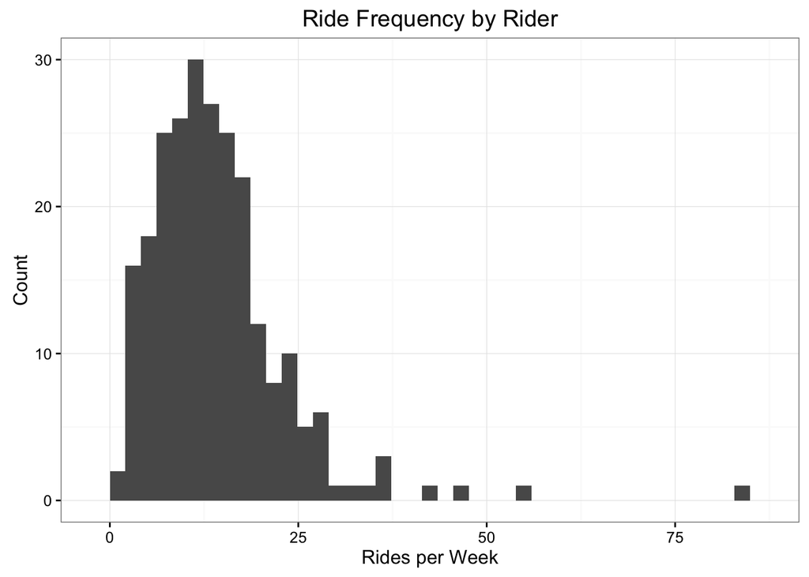

```r
# Compute rider averages
riders <- rides_scaled %>%
  group_by(rider) %>%
  summarise(first_date = min(datetime),
            last_date = max(datetime),
            count = n(),
            prop_weekend = sum(weekend == TRUE) / count) %>%
  mutate(freq = 7 * count / as.numeric(last_date - first_date))

qplot(x = freq, data = riders, bins = 40) +
  labs(title = "Ride Frequency by Rider",
  x = "Rides per Week",
  y = "Count") +
  theme_bw()
```

# Game plan

Okay, so here’s the game plan:

1. Compute freq of rides
2. Do PCA for length and time patterns (would quantiles work better for length?)
3. Take freq. of rides, PC1 & PC2 from length and time patterns
4. Do clustering of riders
5. Plot avg pattern for each cluster, describe

## Length patterns

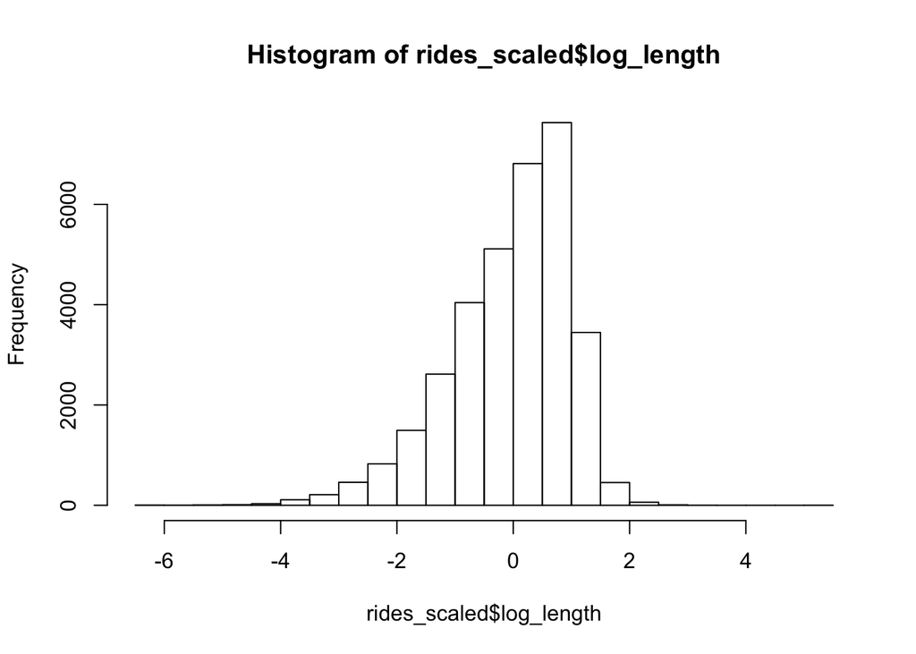

```r
hist(rides_scaled$log_length)
```

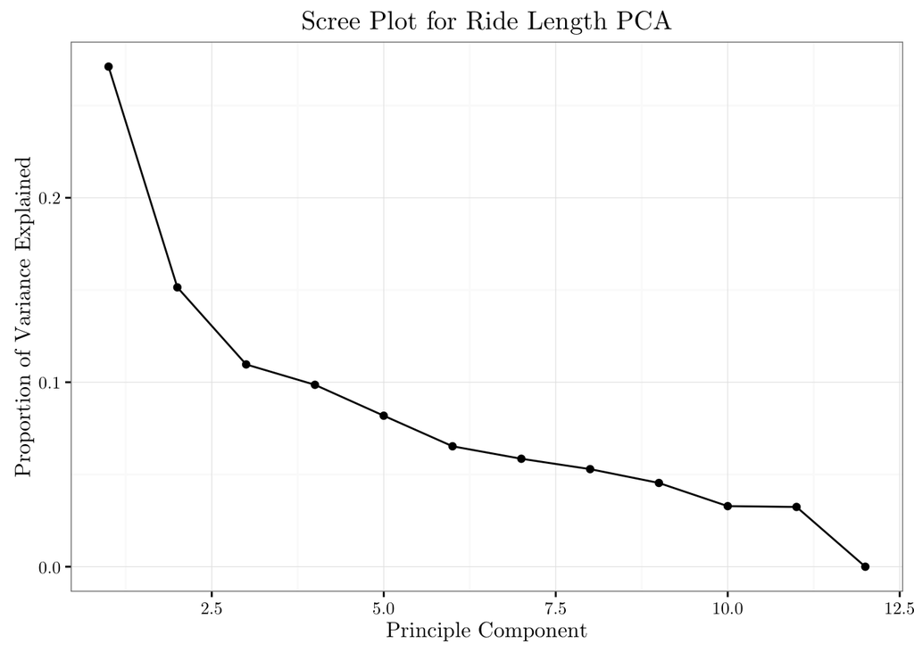

```r
bins <- 12
rider_length_table <- table(as.character(rides_scaled$rider),
      cut(rides_scaled$log_length,
          breaks = seq(from = -5, to = 2, length = bins + 1)))
rider_length_dist <- rider_length_table %>%
  data.frame() %>%
  rename(rider = Var1)

rider_lengths <- spread(rider_length_dist, Var2, Freq)

rider_lengths <- cbind(rider_lengths$rider,
                           rider_lengths[, -1] / rowSums(rider_lengths[, -1])) %>%
  rename(rider = `rider_lengths$rider`)

pc_length <- prcomp(rider_lengths[,-1], scale = TRUE)

length_scree <- qplot(x = 1:bins, y = pc_length$sdev^2 / sum(pc_length$sdev^2)) +
  geom_line() +
  labs(title = "Scree Plot for Ride Length PCA",
       x = "Principle Component",
       y = "Proportion of Variance Explained") +
  theme_bw(base_family="CMU Serif")

length_scree
```

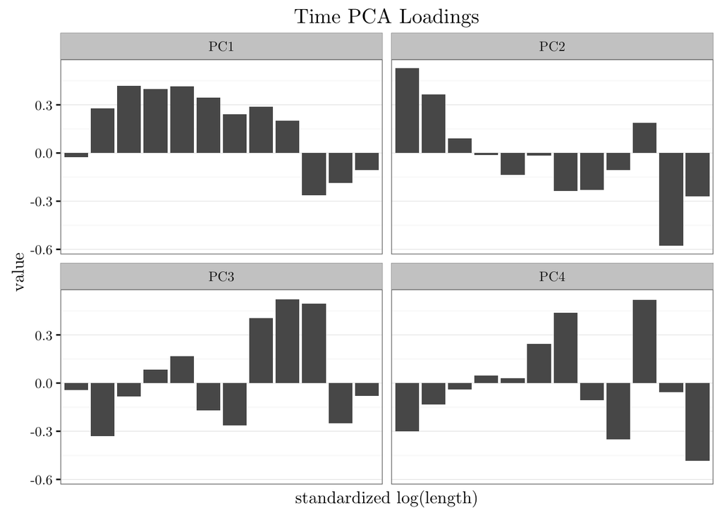

```r
ggsave("plots/length_scree.pdf", width = 3, height = 2)

pc_length_rotation <- data.frame("length" = rownames(pc_length$rotation),
                                 pc_length$rotation) %>%
  tbl_df() %>%
  select(length, PC1, PC2, PC3, PC4) %>%
  gather(pc, value, -length)

length_loadings <- ggplot(pc_length_rotation, aes(x = length, y = value)) +
  geom_bar(stat = "identity") +
  facet_wrap(~pc, ncol = 2)+
  scale_x_discrete(breaks = NULL) +
  theme_bw(base_family="CMU Serif") +
  labs(title = "Time PCA Loadings",
       x = "standardized log(length)")

length_loadings
```

```r
ggsave("plots/length_loadings.pdf", width = 3, height = 2)
```

[output not shown]

[output cut: 40 more lines]

[output not shown]

[output not shown]

```r
rider_lengths_w_pc <- cbind(rider_lengths, pc_length$x)

#qplot(x = PC1, y = PC2, data = rider_lengths_w_pc)
```

## Time Patterns

Let’s try to use PCA to create simple vectors to describe people’s time of ride patterns.

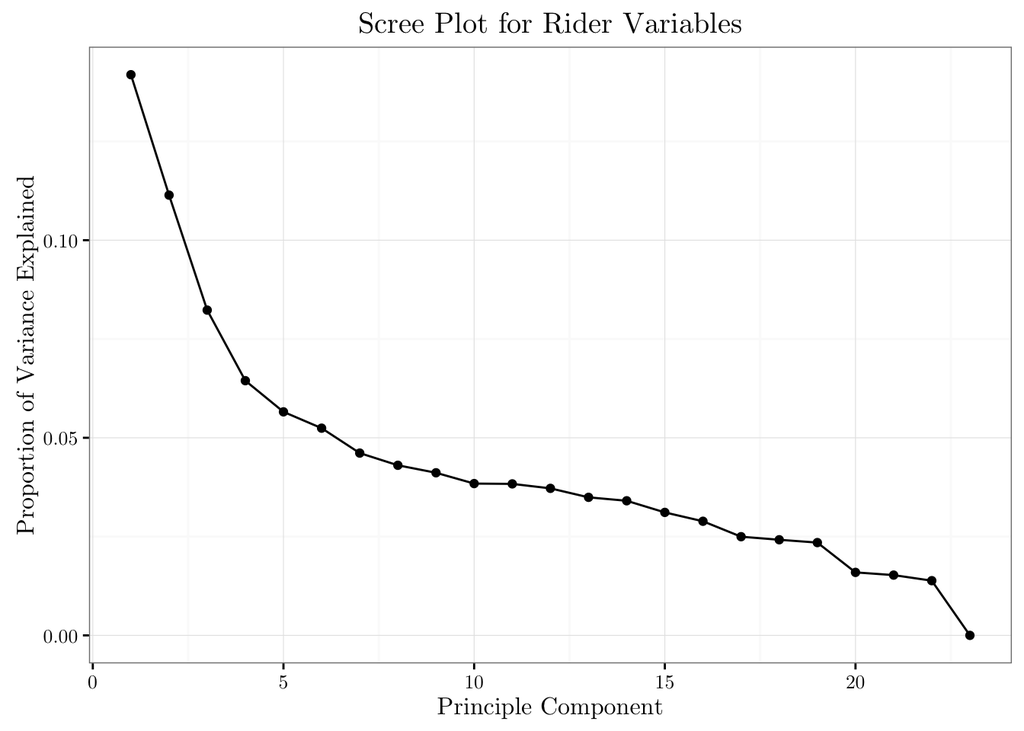

```r
rider_weekday_times <- rides_scaled %>%
  filter(weekend == FALSE) %>%
  mutate(time = floor(time))

rider_times <- table(as.factor(as.numeric(rider_weekday_times$rider)),
                     rider_weekday_times$time) %>%
  data.frame() %>%
  rename(rider = Var1, time = Var2, freq = Freq) %>%
  spread(time, freq)

# Let's normalize the rider times
rider_times <- cbind(rider_times$rider,
                           rider_times[, -1] / rowSums(rider_times[, -1])) %>%
  rename(rider = `rider_times$rider`)

pc <- prcomp(rider_times[,-1], scale=TRUE, retx = TRUE)


qplot(x = 1:23, y = pc$sdev^2 / sum(pc$sdev^2)) +
  geom_line() +
  labs(title = "Scree Plot for Rider Variables",
       x = "Principle Component",
       y = "Proportion of Variance Explained") +
  theme_bw(base_family="CMU Serif")
```

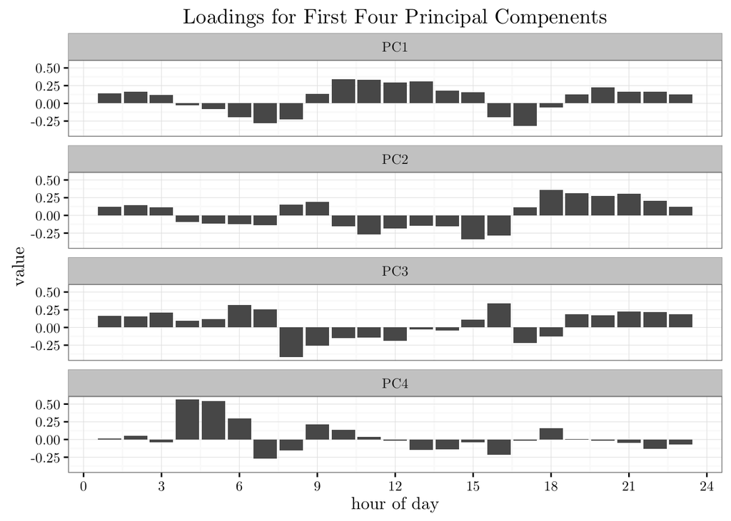

```r
pc_rotation <- data.frame("hour" = 1:23, pc$rotation) %>%
  tbl_df() %>%
  select(hour, PC1, PC2, PC3, PC4) %>%
  gather(pc, value, -hour)

ggplot(pc_rotation, aes(x = hour, y = value)) +
  geom_bar(stat = "identity") +
  facet_wrap(~pc, ncol = 1) +
    theme_bw(base_family="CMU Serif") +
  labs(title = "Loadings for First Four Principal Compenents",
       x = "hour of day") +
  scale_x_continuous(breaks = c(0, 3, 6, 9, 12, 15, 18, 21, 24))
```

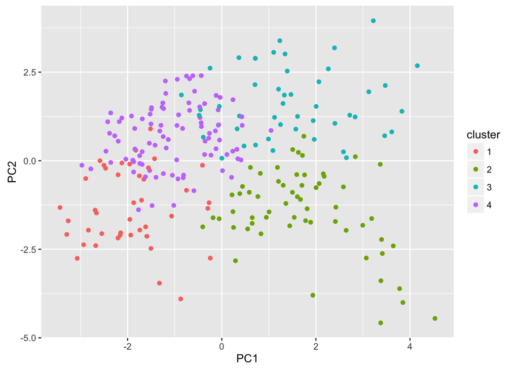

```r
rider_times_w_pc <- cbind(rider_times, pc$x)

clustering <- kmeans(select(rider_times_w_pc, PC1, PC2, PC3, PC4, PC5, PC6), 4, nstart = 30)

rider_times_w_pc$cluster <- as.factor(clustering$cluster)

qplot(x = PC1, y = PC2, color = cluster, data = rider_times_w_pc)
```

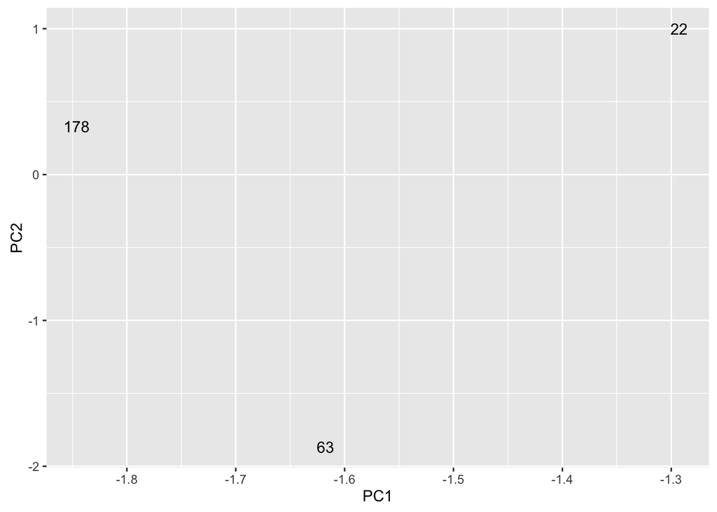

```r
chosen_riders <- c("249", "470", "178", "456", "22", "63", "313", "360", "292")

filter(rider_times_w_pc, rider %in% chosen_riders) %>%
  ggplot(aes(x = PC1, y = PC2, label = rider)) + geom_text()
```

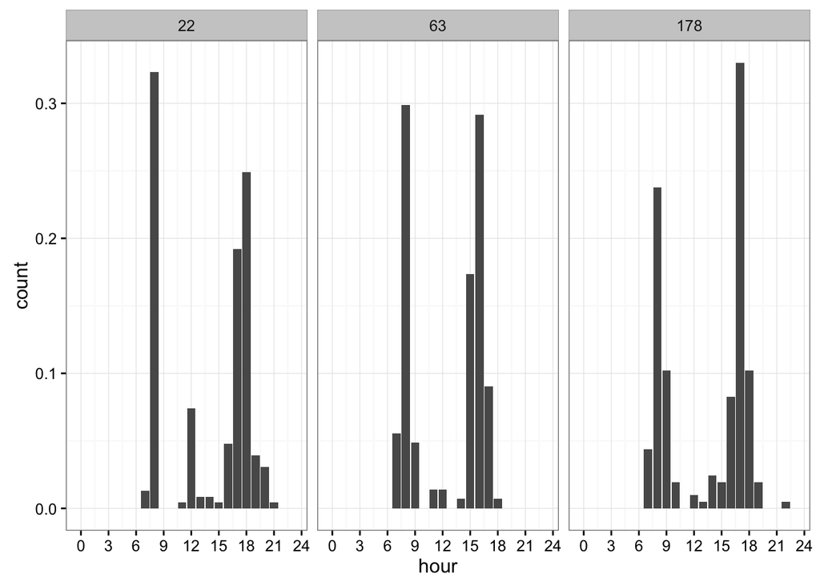

```r
rider_times_representative <- rider_times %>%
  gather(hour, count, 2:24) %>%
  filter(rider %in% chosen_riders) %>%
  mutate(hour = as.numeric(hour))

ggplot(rider_times_representative, aes(x = hour, y = count)) + geom_bar(stat="identity") +
  facet_wrap(~rider, ncol = 3) +
  theme_bw() +
  scale_x_continuous(breaks = c(0, 3, 6, 9, 12, 15, 18, 21, 24))
```

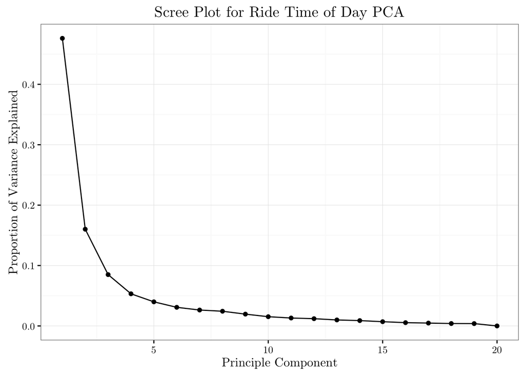

```r
rider_times2 <- data.frame(rider_times[,1],
apply(rider_times[,-1], 1, sort, decreasing = TRUE) %>% t()) %>% tbl_df()

rider_times2 <- rider_times2 %>% select(-X21, -X22, -X23)


pc2 <- prcomp(rider_times2[,-1], scale=TRUE, retx = TRUE)


time_scree <- qplot(x = 1:(ncol(rider_times2)-1), y = pc2$sdev^2 / sum(pc2$sdev^2)) +
  geom_line() +
  labs(title = "Scree Plot for Ride Time of Day PCA",
       x = "Principle Component",
       y = "Proportion of Variance Explained") +
  theme_bw(base_family="CMU Serif")

time_scree
```

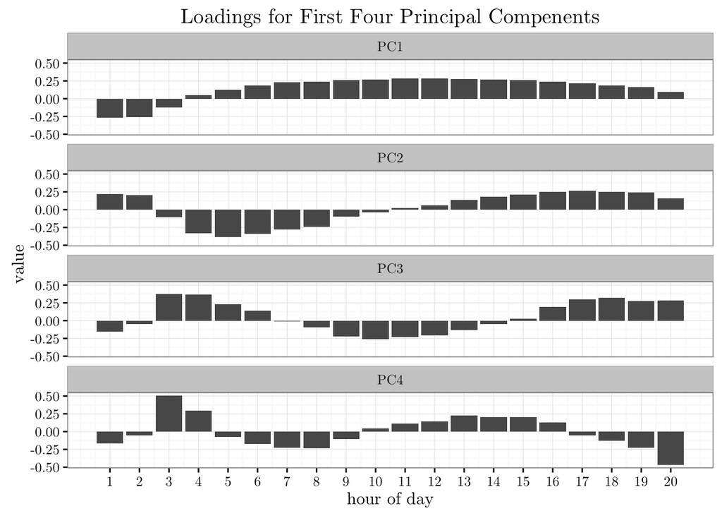

```r
ggsave("plots/time_scree.pdf", width = 3, height = 2)

pc_rotation2 <- data.frame("hour" = 1:(ncol(rider_times2)-1), pc2$rotation) %>%
  tbl_df() %>%
  select(hour, PC1, PC2, PC3, PC4) %>%
  gather(pc, value, -hour)

time_loadings <- ggplot(pc_rotation2, aes(x = hour, y = value)) +
  geom_bar(stat = "identity") +
  facet_wrap(~pc, ncol = 1) +
    theme_bw(base_family="CMU Serif") +
  labs(title = "Loadings for First Four Principal Compenents",
       x = "hour of day") +
  scale_x_continuous(breaks = seq(1, 20))

time_loadings
```

```r
ggsave("plots/time_loadings.pdf", width = 4, height = 4)
```

[output not shown]

[output cut: 76 more lines]

[output not shown]

[output not shown]

[output not shown]

[output not shown]

```r
rider_times_w_pc2 <- cbind(rider_times2, pc2$x) %>% tbl_df() %>%
  rename(rider = rider_times...1.)
```

# Clustering

```r
riders_final <- riders %>%
  left_join(rider_times_w_pc2, by = "rider") %>%
  select(rider, count, freq, prop_weekend, PC1, PC2) %>%
  rename(time_pc1 = PC1, time_pc2 = PC2) %>%
  left_join(select(rider_lengths_w_pc, rider, PC1, PC2), by = "rider") %>%
  rename(length_pc1 = PC1, length_pc2 = PC2)
```

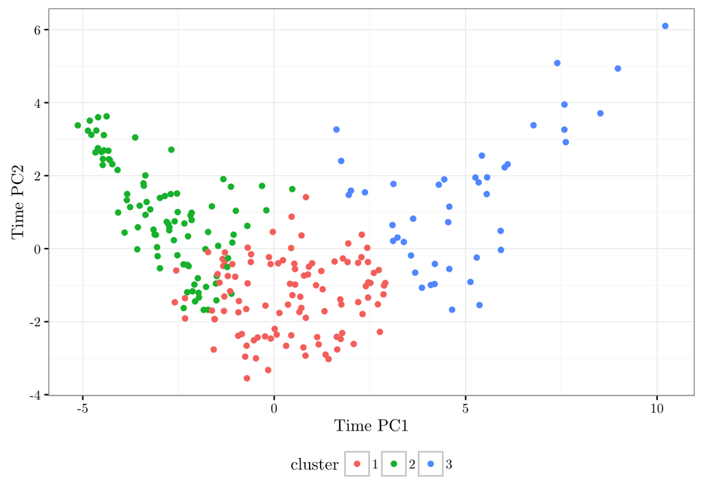

```r
# Need to standardize these variables
scaled_freq <- scale(riders_final$freq)
scaled_weekend <- scale(riders_final$prop_weekend)
riders_final$freq <- scaled_freq[,1]
riders_final$prop_weekend <- scaled_weekend[,1]


clustering <- kmeans(select(riders_final, freq, prop_weekend, time_pc1, time_pc2,
                            length_pc1, length_pc2),
                     3, nstart = 30)

riders_final$cluster <- as.factor(clustering$cluster)

scatter1 <- qplot(x = time_pc1, y = time_pc2, color = cluster, data = riders_final) +
  theme_bw(base_family="CMU Serif") +
  labs(x = "Time PC1", y = "Time PC2") +
  theme(legend.position="bottom")
scatter2 <- qplot(x = length_pc1, y = length_pc2, color = cluster, data = riders_final) + theme_bw(base_family="CMU Serif") +
  labs(x = "Length PC1", y = "Length PC2") +
  theme(legend.position="bottom")
scatter3 <- qplot(x = freq, y = prop_weekend, color = cluster, data = riders_final) + theme_bw(base_family="CMU Serif") +
  labs(x = "rides per week", y = "proportion of rides on weekends") +
  theme(legend.position="bottom")

scatter1
```

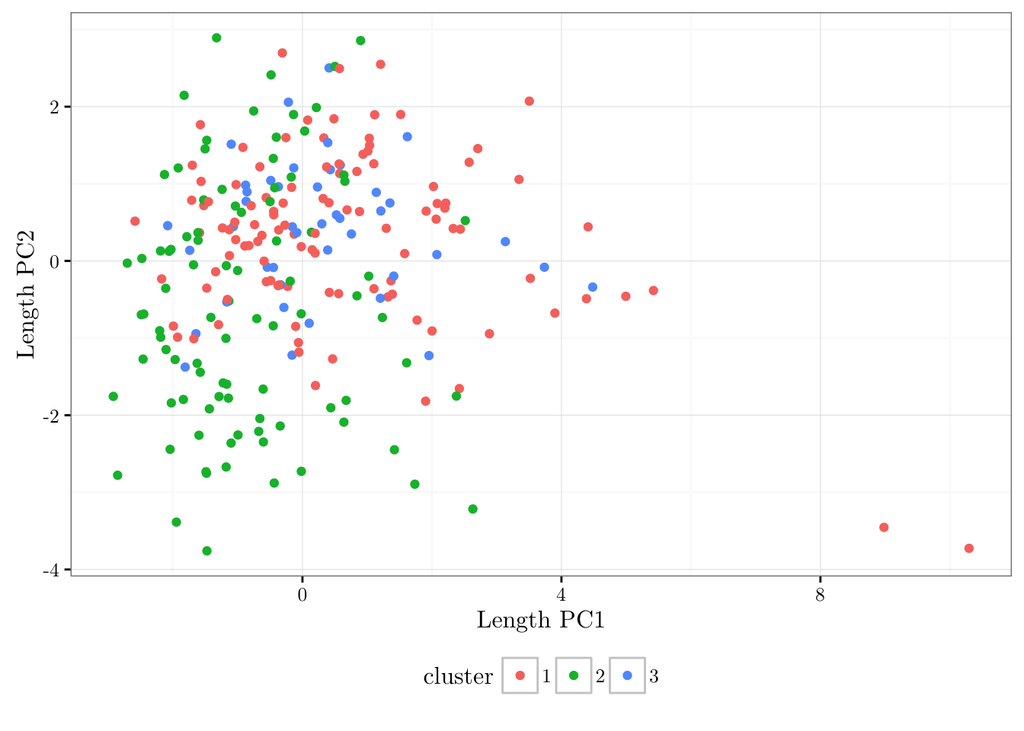

```r
scatter2
```

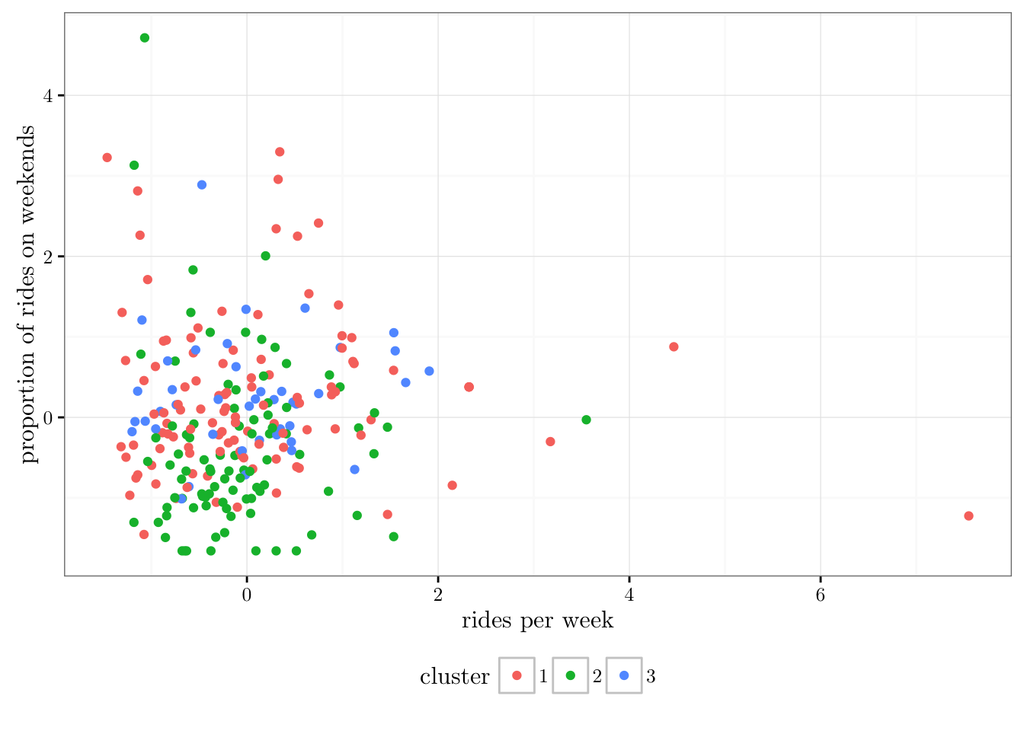

```r
scatter3
```

```r
ggsave("plots/cluster_scatter1.pdf", scatter1, width = 2, height = 2.3)
```

[output not shown]

[output cut: 40 more lines]

[output not shown]

```r
ggsave("plots/cluster_scatter2.pdf", scatter2, width = 2, height = 2.3)
```

[output not shown]

[output cut: 31 more lines]

[output not shown]

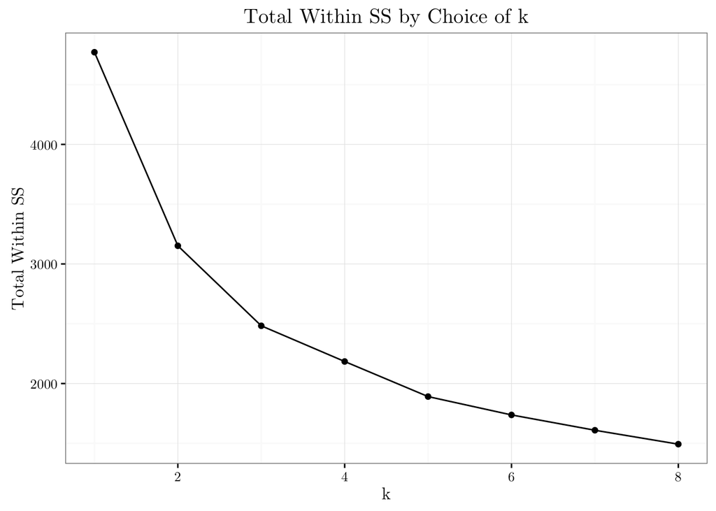

```r
ggsave("plots/cluster_scatter3.pdf", scatter3, width = 2, height = 2.3)


test_k <- function(k) {
  clustering <- kmeans(select(riders_final, freq, prop_weekend, time_pc1, time_pc2,
                            length_pc1, length_pc2),
                     k, nstart = 40)
  clustering$tot.withinss
}
ss <- sapply(1:8, test_k)

choice_k <- qplot(x = 1:8, y = ss) + geom_line() +
  labs(title = "Total Within SS by Choice of k",
       x = "k",
       y = "Total Within SS") +
  theme_bw(base_family="CMU Serif")

choice_k
```

```r
ggsave("plots/choice_k.pdf", width = 3, height = 2)
```

```r
rides_scaled <- select(riders_final, rider, cluster) %>%
  right_join(rides_scaled, by = "rider")
```

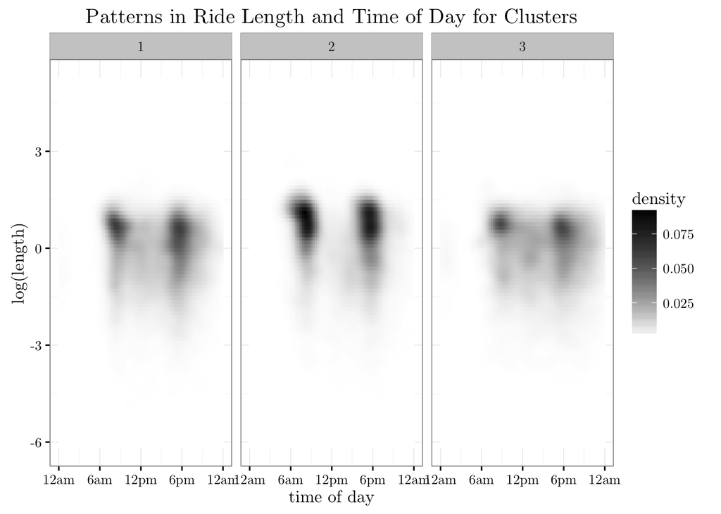

```r
cluster_patterns <- rides_scaled %>%
  filter(weekend == "FALSE") %>%
ggplot(aes(x = time, y = log_length)) +
  stat_density_2d(geom = "raster", aes(fill = ..density..), contour = FALSE) +
    scale_x_continuous(breaks = c(0, 6, 12, 18, 24),
                     labels = c("12am", "6am", "12pm", "6pm", "12am")) +
  facet_wrap(~cluster) +
  scale_fill_gradient(low = "white", high = "black") +
  theme_bw(base_family="CMU Serif") +
  labs(x = "time of day", y = "log(length)",
       title = "Patterns in Ride Length and Time of Day for Clusters")

cluster_patterns
```

```r
ggsave("plots/cluster_patterns.pdf", cluster_patterns, width = 5, height = 3)
```

[output not shown]

[output cut: 19 more lines]

[output not shown]

## What if we fit models with these clusters?

```r
rides_scaled <- left_join(rides_scaled, riders_final, by = "rider")
```

```r
# Add smoother for time of day
model1 <- gamm4(stressful ~ 1 + log_length + mean.temp + gust.speed +
                  rainfall + rainfall.4h  + s(time, bs="cc", k=9, by = weekend) +
                  # rider-level predictors
                  freq + prop_weekend + time_pc1 + time_pc2 + length_pc1 + length_pc2,
                random =~(1|rider),
                knots=list(time=seq(0, 24, 3)),
                data = rides_scaled, family = binomial)

one_day <- 24 #hours
# Add smoother for time of day
model2 <- glmer(stressful ~ 1 + mean.temp + gust.speed +
                  rainfall + rainfall.4h +
                  (log_length +
                     I(sin(2 * pi / one_day * time)):weekend +
                  I(cos(2 * pi / one_day * time)):weekend +
                  I(sin(4 * pi / one_day * time)):weekend +
                  I(cos(4 * pi / one_day * time)):weekend|cluster),
              data = rides_scaled, family=binomial)

model3 <- gamm4(stressful ~ 1 + log_length + mean.temp + gust.speed +
                  rainfall + rainfall.4h  + s(time, bs="cc", k=9, by = weekend),
                random =~(1 + log_length|cluster),
                knots=list(time=seq(0, 24, 3)),
                data = rides_scaled, family = binomial)
```

```r
rides_complete <- rides_scaled %>% filter(!is.na(stressful))

library(rstan)
rstan_options(auto_write = TRUE)
options(mc.cores = parallel::detectCores())
#package the data for stan
data = list(
  num_rides = length(rides_complete$stressful),
  num_cyclists = rides_complete$rider %>% unique() %>% length(),
  # Ride-level variables
  rating = as.numeric(rides_complete$stressful),
  length = as.numeric(rides_complete$log_length),
  mean_temp = as.numeric(rides_complete$mean.temp),
  gust_speed = rides_complete$gust.speed,
  rainfall = rides_complete$rainfall,
  rainfall_4h = rides_complete$rainfall.4h,
  cyclist = as.numeric(rides_complete$rider),
  # Cyclist-level variables
  cyclist_freq = riders_final$freq,
  cyclist_weekend = riders_final$prop_weekend,
  cyclist_time_pc1 = riders_final$time_pc1,
  cyclist_time_pc2 = riders_final$time_pc2,
  cyclist_length_pc1 = riders_final$length_pc1,
  cyclist_length_pc2 = riders_final$length_pc2
)

#compile the model (takes a minute or so)
model = rstan::stan_model(file="rider_model1.stan")

#evaluate the model
sampling_iterations = 2e3 #best to use 1e3 or higher
out = rstan::sampling(
  object = model
  , data = data
  , chains = 2
  , iter = sampling_iterations
  , warmup = sampling_iterations/2
  , refresh = sampling_iterations/10 #show an update @ each %10
  , seed = 1
  , init = list(list(beta_length = 0,
                     sigma_a = 1,
                     a_beta_0 = 0,
                     a_beta_freq = 0),
                list(beta_length = 0,
                     sigma_a = 1,
                     a_beta_0 = 0,
                     a_beta_freq = 0))
)
```